# Shiny App Pitch deck.- Week 4 Project 1.

LR

11/01/2021

# Executive Summary:

The application reads data from a file containing the 20-sessions( approximately monthly) returns of 8 indexes and securities: S&P500, DYX, DJI, Nasdaq100, TNX, IRX, TYX, AAPL. The daily closing of each index/security was sourced from Yahoo finance starting in 1992 and ending in October 2021. The 20-sessions returns (approximately monthly) are calculated daily, rolling daily. Returns at any point in time are computed as the closing of that date minus the closing 20 sessions ago, divided by closing 20 sessions ago, times 100. Based on the input from the user, the application does the following: 1) computes a regression line between the index or security and the S&P500 index. The slope of the line is “beta” for that index. 2) plots the cloud of data points, and the regression line.

User interface, files, and data: Moves the slide to provide a reactive input to the application. You are basically selecting the security or index for which beta will be calculated. The application responds with the following output: 1) the ticker of the index or security followed by “Re” (Re means returns). 2) the full name of the security. 3) beta for the security. 4) plot of the data points cloud, and regression line. In this presentation, we also show you the regression statistics, which the app will be able to present in future versions. Don’t miss the upgrades ! …:)…..

Files and data: 1) Two files, one for user interface, and one for server are included. 2) One data file is included and must be placed in the same directory along with the rest of the files. 3) This documentation file.

# Regression Outputs:

In the next release, the app will also provide the complete regression stats. Take a look:

```
 Line 159:  AAPLRe
Line 151: formulaAAPLRe ~ SP500Re
<environment: 0x00000000127454a0>

Call:
lm(formula = fm, data = df)

Residuals:
    Min      1Q  Median      3Q     Max
-61.471  -5.861  -0.045   5.722  91.282

Coefficients:
            Estimate Std. Error t value Pr(>|t|)
(Intercept)  1.34692    0.12660   10.64   <2e-16 ***
SP500Re      1.16912    0.02932   39.88   <2e-16 ***
---
Signif. codes:  0 '***' 0.001 '**' 0.01 '*' 0.05 '.' 0.1 ' ' 1

Residual standard error: 10.81 on 7488 degrees of freedom
Multiple R-squared:  0.1752,    Adjusted R-squared:  0.1751
F-statistic:  1590 on 1 and 7488 DF,  p-value: < 2.2e-16


[1] "AAPLRe"
```

# Example: plot AAPL monthly returns vs S&P500.

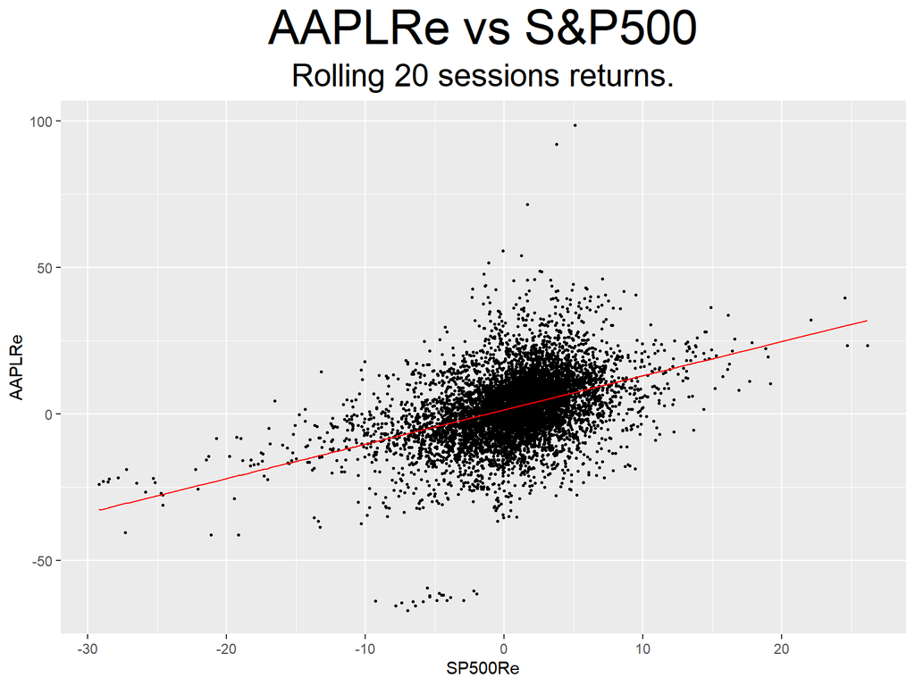

# Time summary.

The app is quick to run !

```
Time Summary:
```

```
Library Loading :  3.79 secs
```